# Clase 9 - Probabilidades Empíricas

Sam

2025-02-18

# Introducción

Las probabilidades empíricas parten totalmente de la simulación de un comportamiento.

Vamos a simular el comportamiento del precio de un activo que está determinado por la ecuación

$$dS=0.25Sdt+0.15SdW$$

Con parámetros anuales y valor inicial de 10.

Usaremos este comportamiento para determinar probabilidades sobre el precio. Lo primero que necesito es determinar quién es S, que sigue el comportamiento descrito por la ecuación dS.

Para determinar S, usamos el lema de Ito y obtenemos:

$$S_{t+1}=S_t e^{(\mu - \frac{1}{2}\sigma^2)dt+\sigma dW}$$
$$S_{t+1}=S_t e^{(0.25 - \frac{1}{2}0.15^2)dt+0.15 dW}$$

Usaremos la ecuación para generar simulaciones y obtner lo siguiente:

- Precio Esperado para dentro de un año
- Probabilidad de que el precio sea mayor a 10 en un año
- Probabilidad de que el precio supere 12 en un año
- Probabilidad de que el precio se ubique entre 11 y 13 en un año
- Intervalo de confianza para el precio en un año al 90%

# Simulación

## Definimos valores iniciales

```r
set.seed(123)
So <- 10
mu <- 0.25
sigma <- 0.15
T <- 1 #Intervalo de tiempo de predicción
dt <- T/252 #Pasos intermedio de predicción para ver la trayectoria del precio
t <- seq(0,T, length.out=252) #Cada paso intermedio
```

## Proceso de Wiener

Vamos a simular dW, el proceso de Wiener

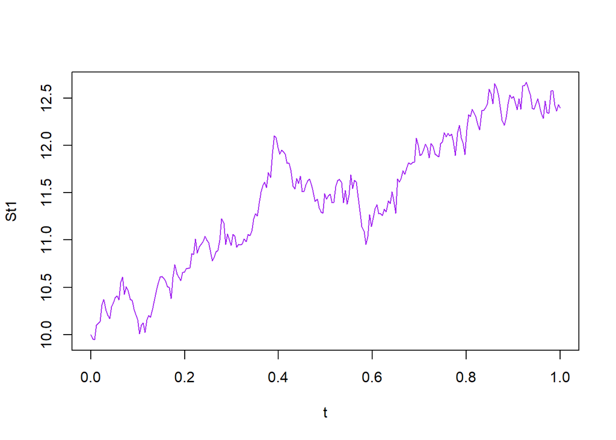

```r
W <- c(0,cumsum(sqrt(dt)*rnorm(251)))
St1 <- So*exp((mu-0.5*sigma^2)*t+sigma*W)
plot(t, St1, type='l',col='purple')
```

## Múltiples simulaciones

Vamos a hacer múltiples simulaciones de este comportamiento

```r
sim <- 1000000
#Vector con todos los posibles valores finales
p_final <- numeric(sim)

for (i in 1:sim) {
  W <- c(0,cumsum(sqrt(dt)*rnorm(251)))
  St1 <- So*exp((mu-0.5*sigma^2)*t+sigma*W)
  p_final[i] <- St1[252]
}
```

La distribución de probabilidad del precio para dentro de un año con un millón de simulaciones es:

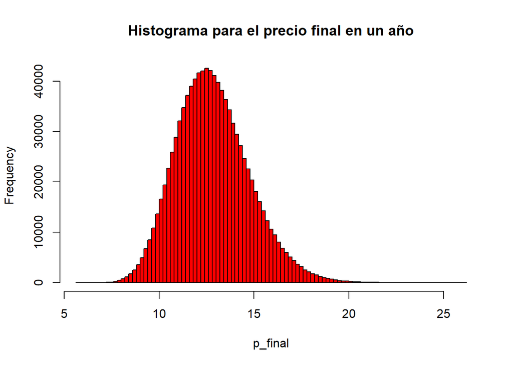

```r
hist(p_final, n=100, col='red', main='Histograma para el precio final en un año')
```

# Cálculos

Precio esperado:

```r
mean(p_final)
```

```
## [1] 12.84015
```

Probabilidad de que el precio sea mayor a 10 en un año:

```r
mean(p_final>10)
```

```
## [1] 0.944551
```

Probabilidad de que el precio supere 12 en un año:

```r
mean(p_final>12)
```

```
## [1] 0.64729
```

Probabilidad de que el precio se ubique entre 11 y 13 en un año:

```r
mean(p_final>11 & p_final<13)
```

```
## [1] 0.393403
```

Intervalo de confianza para el precio en un año al 90%

```r
quantile(p_final,0.05)
```

```
##     5%
## 9.9267
```

```r
quantile(p_final,0.95)
```

```
##      95%
## 16.23997
```

# Actividad

Bajar el precio de un activo que no cotize en la bolsa mexicana de valores y vas a usar el último año de información para calcular mu y sigma y con eso, vas a determinar la probabilidad de que el precio incremente un 30% de su valor actual a un año.

```r
library(quantmod)
library(lubridate)
clave <- 'AMZN'
datos <- new.env()
getSymbols(clave, from = '2024-02-18', to = today(), env=datos)
```

```
## [1] "AMZN"
```

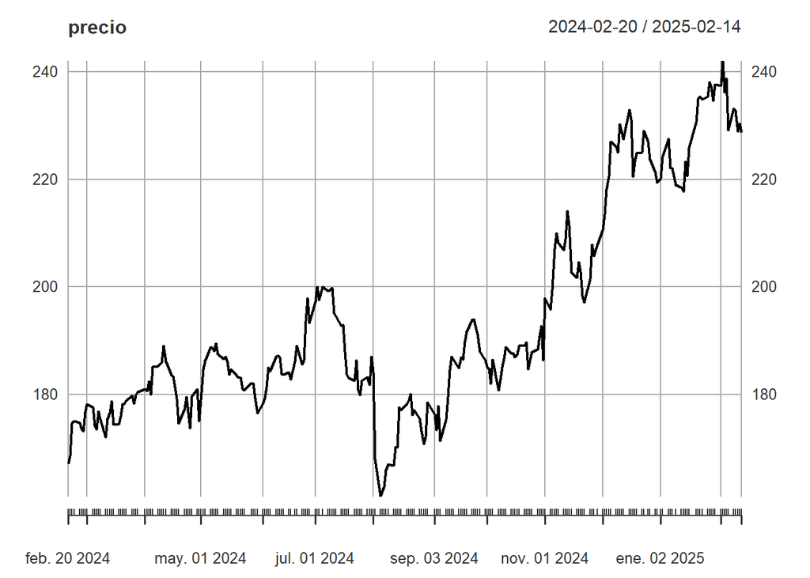

```r
precio <- datos[[clave]][,6]
plot(precio)
```

```r
rendimiento <- na.omit(diff(log(precio)))
mu_act <- mean(rendimiento)*252
sigma_act <- sd(rendimiento)*sqrt(252)
So_act <- as.numeric(precio[length(precio)])
```

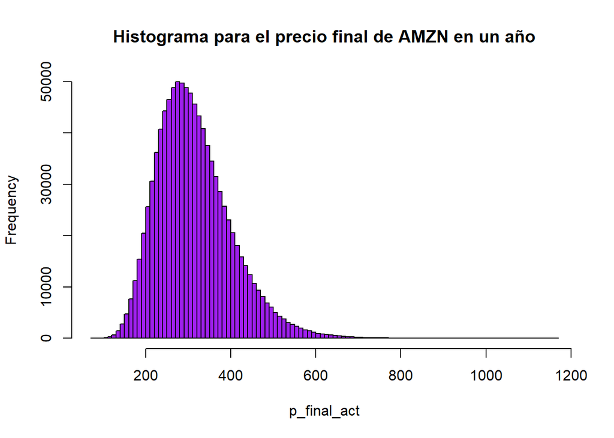

```r
p_final_act <- numeric(sim)

for (i in 1:sim) {
  W <- c(0,cumsum(sqrt(dt)*rnorm(251)))
  St1 <- So_act*exp((mu_act-0.5*sigma_act^2)*t+sigma_act*W)
  p_final_act[i] <- St1[252]
}

hist(p_final_act, n=100, col='purple', main='Histograma para el precio final de AMZN en un año')
```

Probabilidad que el precio del activo aumente un 30% en un año:

```r
St_act <- So_act*1.3
mean(p_final_act > as.numeric(St_act))
```

```
## [1] 0.526991
```